# GEOG 215 Final Project

Maliyah Morrison

2025-04-23

### Topic

This project examines the income gap between SNAP (food stamp) households and non-SNAP households across counties in North Carolina. The topic focuses on measuring economic inequality through differences in median household income. This was done by using data from the 2022 American Community Survey. By looking specifically at North Carolina, the project highlights how income disparities vary across different parts of the state. My research question is: Where in North Carolina is the income gap the biggest between households that get food stamps and those that don’t?

### Interest & Literature

Understanding the income gap between SNAP and non-SNAP households is important because it highlights economic inequalities that affect people’s access to resources. By mapping where these gaps are the largest, we can see how economic hardship is not evenly distributed across North Carolina. Some counties face much greater disparities than others, which can influence everything from local policy decisions to where assistance programs are most needed. This topic matters because programs like SNAP are designed to reduce food insecurity. However, if income gaps remain extremely large, it suggests broader structural economic issues that SNAP alone cannot fix. Identifying geographic patterns of inequality helps target efforts to address poverty and support vulnerable communities more effectively. Research shows that SNAP is more than just a food assistance program. It improves health outcomes, supports local economies, and reduces poverty. By stabilizing household resources, SNAP helps create a healthier, more economically secure population (Center on Budget and Policy Priorities, 2025). Recent research also shows that access to food assistance during childhood, such as through the Food Stamp Program (SNAP), significantly reduces the chances of experiencing poverty in adulthood. The article states, “The Food Stamp Program reduced deep poverty in adulthood by 9 percentage points for Black adults with less-educated parents, stronger than the effects for White adults and for Black adults with more-educated parents” (Glasner et al., 2023). We can see that these effects are especially strong for historically disadvantaged populations, highlighting the critical role of SNAP.

### Methods

To answer the research question, I used spatial analysis techniques applied to American Community Survey (ACS) 2022 data at the county level in North Carolina. I created thematic (choropleth) maps to visualize the median income of SNAP households, median income of non-SNAP households, and the income gap between non-SNAP and SNAP households. For spatial pattern analysis: I calculated descriptive statistics to summarize the distribution of income gaps across counties. I calculated the mean center and standard distance of the income gap variable to show the geographic concentration and spread of disparities. For hot-spot analysis, I used a formal spatial statistical method, the Getis-Ord Gi statistic. This approach identifies counties where high or low income gaps are clustered together more than would be expected by random chance. Counties were classified as “very hot,” “hot,” “somewhat hot,” “cold,” or “very cold” based on the significance of their clustering. This method accounts for spatial relationships between neighboring counties, providing a more rigorous identification of geographic patterns of income inequality.

## Exploratory Spatial Data Analysis

### Both data sets were retrieved from the U.S. Census Bureau’s American Community Survey (ACS) 5-Year Estimates (2022), accessed through the tidycensus R package in R. U.S. Census Bureau. (2022). The data set covers the entire state of North Carolina, including all 100 counties. The spatial resolution is at the county level since resolution is ideal for comparing broad regional patterns across the state. The data reflects the ACS 5-Year Estimates for 2018–2022, with 2022 as the release year. These estimates are based on data collected over five years, providing stable values for geographic areas like counties. Retrieved from: *American Community Survey 5-Year Estimates (Table B22008)*. Retrieved from https://www.census.gov/programs-surveys/acs.

### Descriptive Statistics

```r
# Load the libraries used in the research
library(tidyverse)
library(tidycensus)
library(tigris)
library(sf)
library(sfdep)
library(spdep)
library(tmap)
```

```r
# load the 2020 NC counties

ncCounties <- read_sf("https://drive.google.com/uc?export=view&id=1Ks38Gmdlp58GBhOgb6FBmx8tIAfu0QDw")
glimpse(ncCounties)
```

```
## Rows: 100
## Columns: 97
## $ GEOID                                    <chr> "37083", "37179", "37129", "3…
## $ NAME                                     <chr> "Halifax County, North Caroli…
## $ popE                                     <dbl> 50678, 235767, 231448, 63284,…
## $ popM                                     <dbl> NA, NA, NA, NA, NA, 48, NA, N…
## $ maleE                                    <dbl> 24445, 116112, 110218, 31128,…
## $ maleM                                    <dbl> 170, 46, 271, 60, 127, 110, 1…
## $ femaleE                                  <dbl> 26233, 119655, 121230, 32156,…
## $ femaleM                                  <dbl> 170, 46, 271, 60, 127, 105, 1…
## $ white.aloneE                             <dbl> 20078, 187121, 186681, 38439,…
## $ white.aloneM                             <dbl> 301, 1207, 1030, 951, 238, 37…
## $ black.aloneE                             <dbl> 26439, 27297, 30436, 16115, 3…
## $ black.aloneM                             <dbl> 390, 786, 772, 367, 266, 2073…
## $ native.aloneE                            <dbl> 1771, 574, 544, 1318, 212, 34…
```

[output cut: 84 more lines]

```r
# Set up Census API key to access ACS data
census_api_key("fcc03e3b539f409e5cc041b38be5966d3eaacffa", install = TRUE, overwrite = TRUE)
```

```
## Your original .Renviron will be backed up and stored in your R HOME directory if needed.
```

```
## Your API key has been stored in your .Renviron and can be accessed by Sys.getenv("CENSUS_API_KEY").
## To use now, restart R or run `readRenviron("~/.Renviron")`
```

```
## [1] "fcc03e3b539f409e5cc041b38be5966d3eaacffa"
```

```r
# Refresh environment to use the API key immediately
readRenviron("~/.Renviron")
```

```r
# View available ACS variables for 2022 5-Year Estimates
view(load_variables(2022, "acs5", cache = TRUE))
```

```r
# Download ACS data for NC counties: median income for all, SNAP households, and non-SNAP households
nc_data <- get_acs(geography = "county",
              variables = c(income_all = "B22008_001",
                            income_snap = "B22008_002",
                            income_non_snap = "B22008_003"),
              state = "NC",
              year = 2022)
# Display the data
nc_data
```

```
## # A tibble: 300 × 5
##    GEOID NAME                             variable        estimate   moe
##    <chr> <chr>                            <chr>              <dbl> <dbl>
##  1 37001 Alamance County, North Carolina  income_all         60866  2024
##  2 37001 Alamance County, North Carolina  income_snap        27943  2062
##  3 37001 Alamance County, North Carolina  income_non_snap    66925  1824
##  4 37003 Alexander County, North Carolina income_all         62764  4812
##  5 37003 Alexander County, North Carolina income_snap        29452  9271
##  6 37003 Alexander County, North Carolina income_non_snap    67221  4605
##  7 37005 Alleghany County, North Carolina income_all         42115  6307
##  8 37005 Alleghany County, North Carolina income_snap        16639  4310
##  9 37005 Alleghany County, North Carolina income_non_snap    47630  5260
## 10 37007 Anson County, North Carolina     income_all         42000  4659
## # ℹ 290 more rows
```

```r
income_snap <- nc_data |>
  select(GEOID, NAME, variable, estimate) |>
  pivot_wider(names_from = variable, values_from = estimate) |>
  mutate(income_gap = income_non_snap - income_snap)
```

```r
# Join reshaped income data to the spatial county shapes
nc_income_map <- ncCounties |>
  left_join(income_snap, by = "GEOID")
```

```r
# Descriptive statistics for SNAP households' income
summary(nc_income_map$income_snap)
```

```
##    Min. 1st Qu.  Median    Mean 3rd Qu.    Max.
##   12398   20946   25151   25078   28728   41576
```

```r
sd(nc_income_map$income_snap, na.rm = TRUE)
```

```
## [1] 5797.672
```

The median household income for SNAP recipients across North Carolina counties ranges from $12,398 to $41,576, with an average of $25,078. The standard deviation of approximately $5,798 suggests moderate variation, meaning SNAP households in most counties fall within a fairly narrow income band, but some areas have notably higher or lower medians.

```r
# Descriptive statistics for non-SNAP households' income
summary(nc_income_map$income_non_snap)
```

```
##    Min. 1st Qu.  Median    Mean 3rd Qu.    Max.
##   47630   56385   62232   64949   70048  101883
```

```r
sd(nc_income_map$income_non_snap, na.rm = TRUE)
```

```
## [1] 11461.24
```

Non-SNAP households show significantly higher income levels, with medians ranging from $47,630 to $101,883. The average is $64,949, and the standard deviation of $11,461 indicates greater variation in income compared to SNAP households. This likely reflects broader economic diversity across counties.

```r
# Descriptive statistics for income gap
summary(nc_income_map$income_gap)
```

```
##    Min. 1st Qu.  Median    Mean 3rd Qu.    Max.
##   22468   34509   38130   39871   44262   69675
```

```r
sd(nc_income_map$income_gap, na.rm = TRUE)
```

```
## [1] 9434.205
```

The income gap between non-SNAP and SNAP households varies widely by county. On average, non-SNAP households earn $39,871 more than SNAP households. The gap ranges from $22,468 to $69,675, with a standard deviation of $9,434, showing noticeable inequality in household incomes across counties.

### Initial Maps

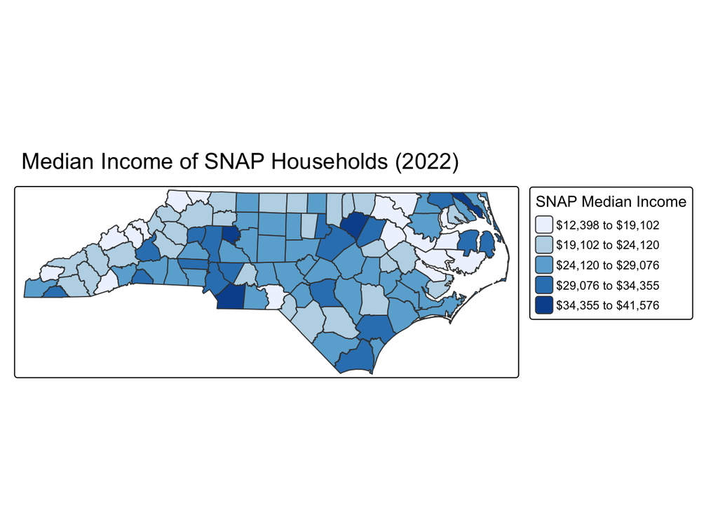

```r
# Map of SNAP household income
map_snap <- tm_shape(nc_income_map) +
  tm_polygons(
    fill = "income_snap",
    fill.scale = tm_scale_intervals(
      style = "jenks",
      values = "brewer.blues",
      label.format = list(fun = function(x) paste0("$", formatC(x, format = "f", digits = 0, big.mark = ",")))
    ),
    fill.legend = tm_legend("SNAP Median Income", position = tm_pos_out(pos.h = "right"))
  ) +
  tm_title("Median Income of SNAP Households (2022)")

# View map
map_snap
```

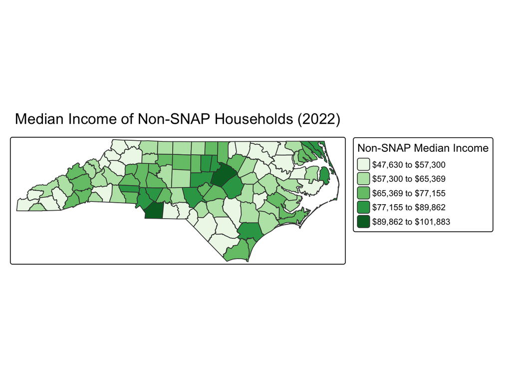

```r
# Map of non-SNAP household income
map_non_snap <- tm_shape(nc_income_map) +
  tm_polygons(
    fill = "income_non_snap",
    fill.scale = tm_scale_intervals(
      style = "jenks",
      values = "brewer.greens",
      label.format = list(fun = function(x) paste0("$", formatC(x, format = "f", digits = 0, big.mark = ",")))
    ),
    fill.legend = tm_legend("Non-SNAP Median Income", position = tm_pos_out(pos.h = "right"))
  ) +
  tm_title("Median Income of Non-SNAP Households (2022)")

# View map
map_non_snap
```

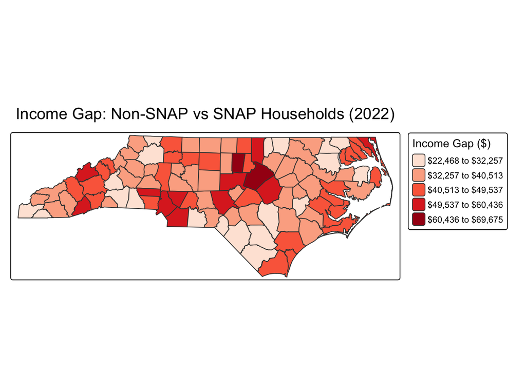

```r
# Map of income gap between non-SNAP and SNAP households
map_gap <- tm_shape(nc_income_map) +
  tm_polygons(
    fill = "income_gap",
    fill.scale = tm_scale_intervals(
      style = "jenks",
      values = "brewer.reds",
      label.format = list(fun = function(x) paste0("$", formatC(x, format = "f", digits = 0, big.mark = ",")))
    ),
    fill.legend = tm_legend("Income Gap ($)", position = tm_pos_out(pos.h = "right"))
  ) +
  tm_title("Income Gap: Non-SNAP vs SNAP Households (2022)")

# View map
map_gap
```

[output not shown]

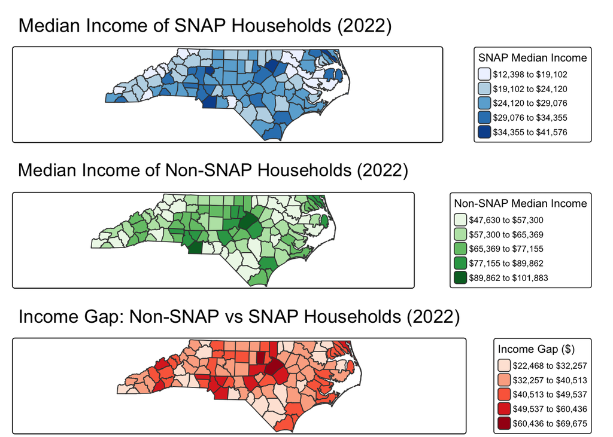

```r
# Arrange the three maps vertically
tmap_arrange(map_snap, map_non_snap, map_gap, ncol = 1)
```

### Spatial Statistics

```r
# Calculate the centroid of each county
county_centroids <- st_centroid(nc_income_map)
# Keep centroids with valid income_gap data
centroids_with_gap <- county_centroids |>
  filter(!is.na(income_gap)) |>
  mutate(weight = income_gap)

# Extract coordinates
coords <- st_coordinates(centroids_with_gap)

# Weighted mean center calculation
mean_center_x <- weighted.mean(coords[, 1], centroids_with_gap$weight)
mean_center_y <- weighted.mean(coords[, 2], centroids_with_gap$weight)
mean_center <- st_point(c(mean_center_x, mean_center_y)) |> st_sfc(crs = st_crs(nc_income_map))

# Calculate standard distance
dists_squared <- (coords[,1] - mean_center_x)^2 + (coords[,2] - mean_center_y)^2
std_distance <- sqrt(weighted.mean(dists_squared, centroids_with_gap$weight))

# Create circle around mean center
std_circle <- st_buffer(mean_center, dist = std_distance)
```

```
## [cols4all] color palettes: use palettes from the R package cols4all. Run
## `cols4all::c4a_gui()` to explore them. The old palette name "Reds" is named
## "brewer.reds"
## Multiple palettes called "reds" found: "brewer.reds", "matplotlib.reds". The first one, "brewer.reds", is returned.
```

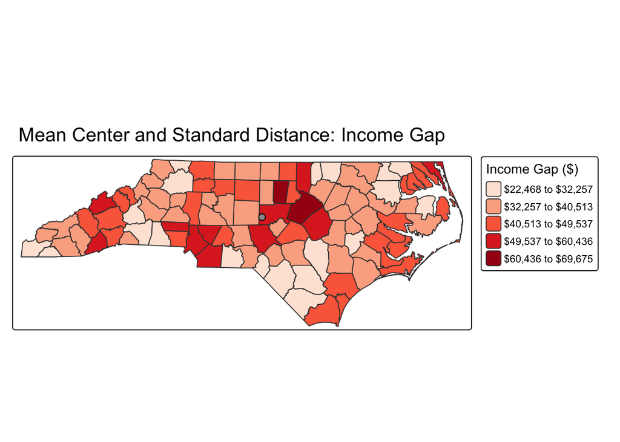

```r
# Map: Income gap with mean center and standard distance circle
tm_shape(nc_income_map) +
  tm_polygons(
    fill = "income_gap",
    fill.scale = tm_scale_intervals(
      style = "jenks",
      values = "Reds",
      label.format = list(fun = function(x) paste0("$", formatC(x, format = "f", digits = 0, big.mark = ",")))
    ),
    fill.legend = tm_legend("Income Gap ($)", position = tm_pos_out(pos.h = "right"))
  ) +
  tm_shape(std_circle) +
  tm_borders(col = "black", lwd = 2, lty = "dashed") +
  tm_shape(mean_center) +
  tm_symbols(shape = 21, col = "black", size = 0.5) +
  tm_title("Mean Center and Standard Distance: Income Gap")
```

### Hot-Spot Analysis

```r
# Create the neighborhoods and weights
nbhds <- st_contiguity(nc_income_map, queen = TRUE)
wts <- st_weights(nbhds, style = "W")

# Global Moran's I to check clustering
moran <- global_moran(nc_income_map$income_gap, nbhds, wts)
moran
```

```
## $I
## [1] 0.3101503
##
## $K
## [1] 3.649577
```

```r
nb_nc <- poly2nb(nc_income_map, queen = TRUE)
nc_binary <- nb2listw(nb_nc, style = "B")

# Global G test on income gap
globalG.test(nc_income_map$income_gap, nc_binary)
```

```
##
##  Getis-Ord global G statistic
##
## data:  nc_income_map$income_gap
## weights: nc_binary
##
## standard deviate = 2.0664, p-value = 0.0194
## alternative hypothesis: greater
## sample estimates:
## Global G statistic        Expectation           Variance
##       5.113867e-02       4.949495e-02       6.327575e-07
```

```r
# Neighbor and weight information per county
nc_nbs <- nc_income_map |>
  mutate(
    nb = st_contiguity(geometry),
    wt = st_weights(nb),
    lag = st_lag(income_gap, nb, wt)
  )

# Run local G hot spot analysis
nc_hot_spots <- nc_nbs |>
  mutate(
    Gi = local_g_perm(income_gap, nb, wt, nsim = 999)
  ) |>
  unnest(Gi)
```

These test results show statistically significant clustering of high income gap values in North Carolina. This means counties with large income gaps between SNAP and non-SNAP households tend to be located near other counties with similarly large gaps, rather than being randomly distributed across the state.

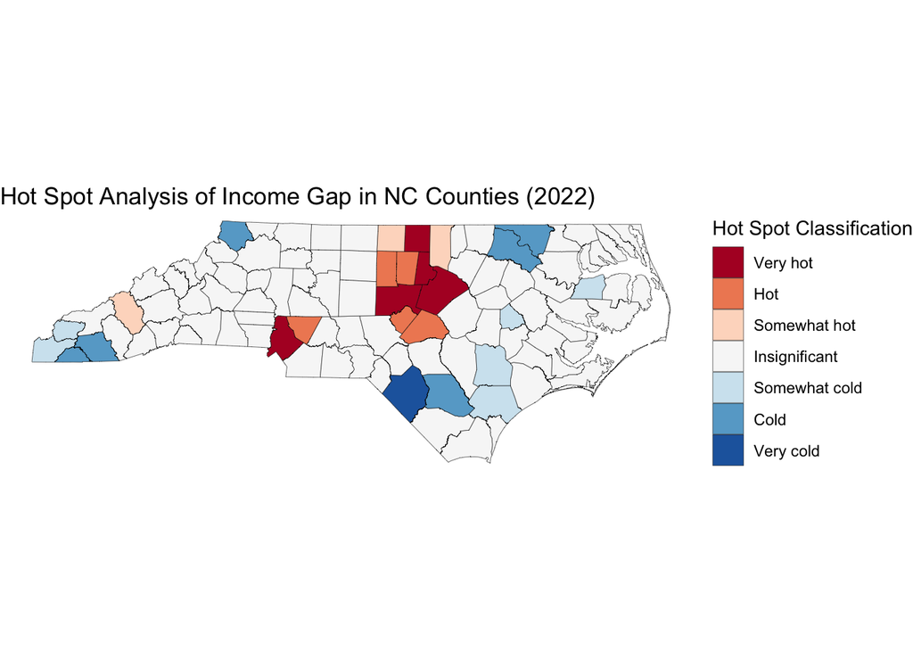

```r
# Classify counties based on hot and cold spots
nc_hot_spots |>
  select(gi, p_folded_sim) |>
  mutate(
    classification = case_when(
      gi > 0 & p_folded_sim <= 0.01 ~ "Very hot",
      gi > 0 & p_folded_sim <= 0.05 ~ "Hot",
      gi > 0 & p_folded_sim <= 0.1 ~ "Somewhat hot",
      gi < 0 & p_folded_sim <= 0.01 ~ "Very cold",
      gi < 0 & p_folded_sim <= 0.05 ~ "Cold",
      gi < 0 & p_folded_sim <= 0.1 ~ "Somewhat cold",
      TRUE ~ "Insignificant"
    ),
    classification = factor(
      classification,
      levels = c("Very hot", "Hot", "Somewhat hot",
                 "Insignificant",
                 "Somewhat cold", "Cold", "Very cold")
    )
  ) |>
  ggplot(aes(fill = classification)) +
  geom_sf(color = "black", lwd = 0.1) +
  scale_fill_brewer(type = "div", palette = 5) +
  theme_void() +
  labs(
    fill = "Hot Spot Classification",
    title = "Hot Spot Analysis of Income Gap in NC Counties (2022)"
  )
```

### Results

This section presents maps and descriptive statistics that summarize patterns of income inequality between SNAP and non-SNAP households across North Carolina counties.

[output not shown]

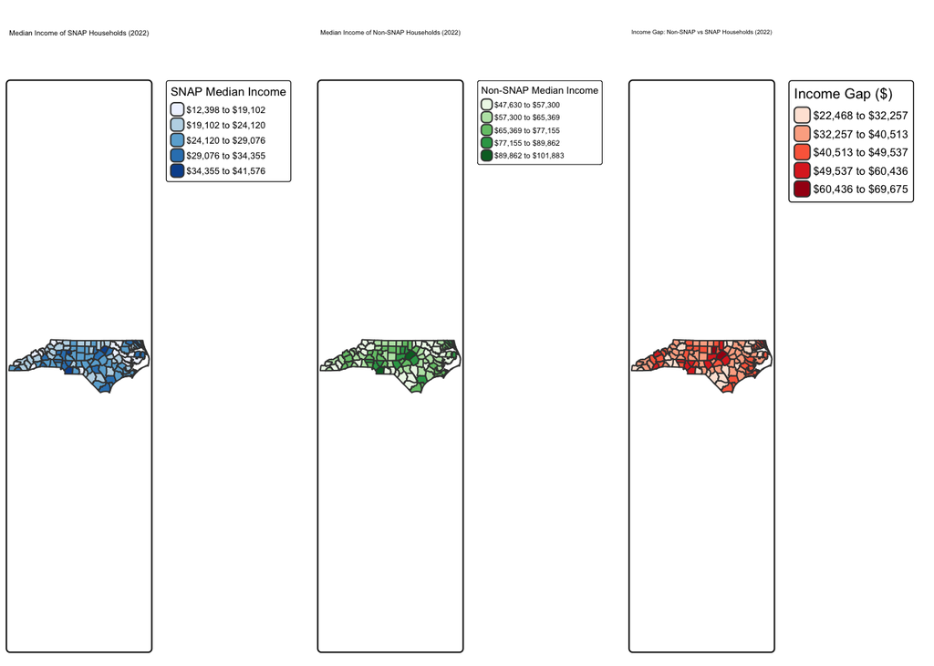

```r
tmap_arrange(map_snap, map_non_snap, map_gap, ncol = 3)
```

The first map shows the median income of SNAP households, generally much lower across all counties. The second map shows median income for non-SNAP households, revealing significantly higher incomes overall. The third map visualizes the income gap, highlighting counties where disparities are especially wide.

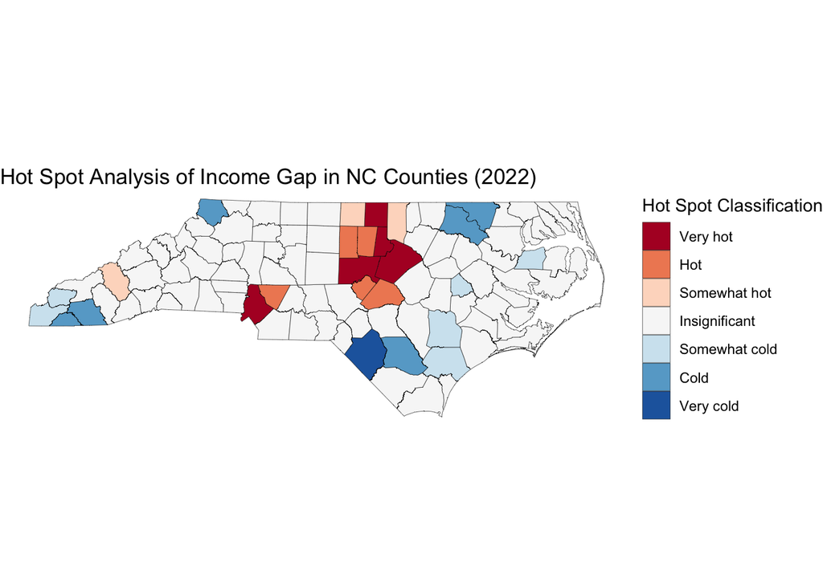

```r
nc_hot_spots |>
  select(gi, p_folded_sim) |>
  mutate(
    classification = case_when(
      gi > 0 & p_folded_sim <= 0.01 ~ "Very hot",
      gi > 0 & p_folded_sim <= 0.05 ~ "Hot",
      gi > 0 & p_folded_sim <= 0.1 ~ "Somewhat hot",
      gi < 0 & p_folded_sim <= 0.01 ~ "Very cold",
      gi < 0 & p_folded_sim <= 0.05 ~ "Cold",
      gi < 0 & p_folded_sim <= 0.1 ~ "Somewhat cold",
      TRUE ~ "Insignificant"
    ),
    classification = factor(
      classification,
      levels = c("Very hot", "Hot", "Somewhat hot",
                 "Insignificant",
                 "Somewhat cold", "Cold", "Very cold")
    )
  ) |>
  ggplot(aes(fill = classification)) +
  geom_sf(color = "black", lwd = 0.1) +
  scale_fill_brewer(type = "div", palette = 5) +
  theme_void() +
  labs(
    fill = "Hot Spot Classification",
    title = "Hot Spot Analysis of Income Gap in NC Counties (2022)"
  )
```

Hot spots (counties with very high income gaps clustered together) are located primarily in the Piedmont region (center of the state). Cold spots (low gaps) are seen in parts of the coastal and southwestern counties. Many counties were classified as insignificant, suggesting that not all areas have strong spatial clustering of income inequality.

```r
tm_shape(nc_income_map) +
  tm_polygons(
    fill = "income_gap",
    fill.scale = tm_scale_intervals(
      style = "jenks",
      values = "Reds",
      label.format = list(fun = function(x) paste0("$", formatC(x, format = "f", digits = 0, big.mark = ",")))
    ),
    fill.legend = tm_legend("Income Gap ($)", position = tm_pos_out(pos.h = "right"))
  ) +
  tm_shape(std_circle) +
  tm_borders(col = "black", lwd = 2, lty = "dashed") +
  tm_shape(mean_center) +
  tm_symbols(shape = 21, col = "black", size = 0.5) +
  tm_title("Mean Center and Standard Distance: Income Gap")
```

```
## [cols4all] color palettes: use palettes from the R package cols4all. Run
## `cols4all::c4a_gui()` to explore them. The old palette name "Reds" is named
## "brewer.reds"
## Multiple palettes called "reds" found: "brewer.reds", "matplotlib.reds". The first one, "brewer.reds", is returned.
```

[figure not shown]

The dot marks the mean center of income gaps across the state, while the dashed circle shows the standard distance spread (it is located directly under the other dot). This helps visualize the geographic concentration and dispersion of income inequality.

```r
summary_table <- data.frame(
  Min = min(nc_income_map$income_gap, na.rm = TRUE),
  Q1 = quantile(nc_income_map$income_gap, 0.25, na.rm = TRUE),
  Median = median(nc_income_map$income_gap, na.rm = TRUE),
  Mean = mean(nc_income_map$income_gap, na.rm = TRUE),
  Q3 = quantile(nc_income_map$income_gap, 0.75, na.rm = TRUE),
  Max = max(nc_income_map$income_gap, na.rm = TRUE),
  SD = sd(nc_income_map$income_gap, na.rm = TRUE)
)

print(summary_table)
```

```
##       Min       Q1 Median     Mean      Q3   Max       SD
## 25% 22468 34508.75  38130 39870.75 44262.5 69675 9434.205
```

The table summarizes the key descriptive statistics for the income gap variable. The average gap is approximately $39,871, with the largest gap reaching nearly $70,000 between SNAP and non-SNAP households in some counties.

### Discussion

The spatial analysis revealed that income inequality between SNAP and non-SNAP households varies significantly across North Carolina. While many counties showed moderate differences, clear clusters of high income gaps emerged in the central Piedmont region, as identified through formal hot-spot analysis using the Getis-Ord G statistic. These “very hot” and “hot” spots indicate regions where households receiving food assistance are at a much greater disadvantage compared to their non-SNAP counterparts. Many counties were classified as “Insignificant” because their income gap values were either average or not strongly clustered with similar counties. Hot-spot analysis using Getis-Ord Gi focuses not just on individual values, but on clusters of high or low values among neighboring areas. This suggests that income inequality in North Carolina is strongly clustered in certain regions but more random or dispersed in others. Descriptive statistics supported these findings, with an average income gap of nearly $40,000 and a considerable range across counties. The mean center and standard distance analysis showed that income inequality is moderately concentrated but still geographically spread throughout the state. What worked well in the project was using formal spatial statistics (rather than simple rankings) to rigorously identify significant patterns. Mapping both the income gap and the hot spots side-by-side made spatial disparities immediately visible and easier to interpret. One challenge was that many counties were classified as “insignificant” in the hot-spot analysis. This happened because spatial statistics require not only high or low values but also similar surrounding counties to detect a cluster, which wasn’t the case everywhere. Another limitation was relying only on income gap data without incorporating other economic or demographic variables that could have provided a fuller picture. If I were to continue this research, I would consider: Using additional variables, like poverty rates or education, to explore deeper patterns. Also, I would consider comparing rural versus urban counties systematically.

### Conclusion

This project explored the spatial distribution of income inequality between SNAP and non-SNAP households across North Carolina using 2022 American Community Survey data. The analysis showed that income gaps are not evenly distributed across the state. Hot spots of high inequality were concentrated mainly in the Piedmont region, while some cold spots appeared in parts of the coastal and southwestern areas. Descriptive statistics highlighted the large differences in household income, and spatial statistics such as the mean center and standard distance helped visualize the geographic spread of these disparities. A formal hot-spot analysis using the Getis-Ord Gi method provided a rigorous identification of areas with statistically significant clustering of high or low income gaps. Overall, spatial data science techniques revealed clear patterns of economic inequality that could inform targeted policy interventions or further research into regional socioeconomic conditions.

### References

Center on Budget and Policy Priorities. (2025). *SNAP Food Assistance Is a Sound Investment in Our Nation’s Health, Well-Being, and Economy.* Retrieved from https://www.cbpp.org/blog/snap-food-assistance-is-a-sound-investment-in-our-nations-health-well-being-and-economy

Glasner, B., Mincy, R. B., Parolin, Z., & Wimer, C. (2023). *The Effectiveness of the Food Stamp Program at Reducing Racial Differences in the Intergenerational Persistence of Poverty*. Washington Center for Equitable Growth. Retrieved from https://povertycenter.columbia.edu/publication/2023/the-effectiveness-of-the-food-stamp-program-on-intergenerational-poverty

U.S. Census Bureau. (2022). *American Community Survey 5-Year Estimates (Table B22008)*. Retrieved from https://www.census.gov/programs-surveys/acs